# ¶

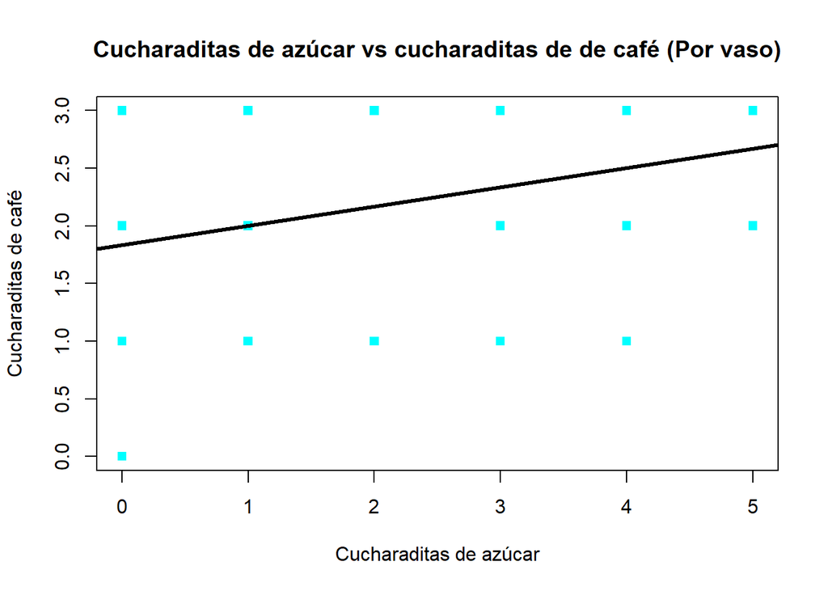

```r
plot(DF1$`Cucharada de azúcar`,DF1$`Cucharada de café`,main = "Cucharaditas de azúcar vs cucharaditas de de café (Por vaso)", xlab= "Cucharaditas de azúcar", ylab= "Cucharaditas de café", col= "cyan",pch=15)
modelo <- lm(DF1$`Cucharada de café` ~ DF1$`Cucharada de azúcar`)
abline(modelo, col = "black", lwd = 3)
```

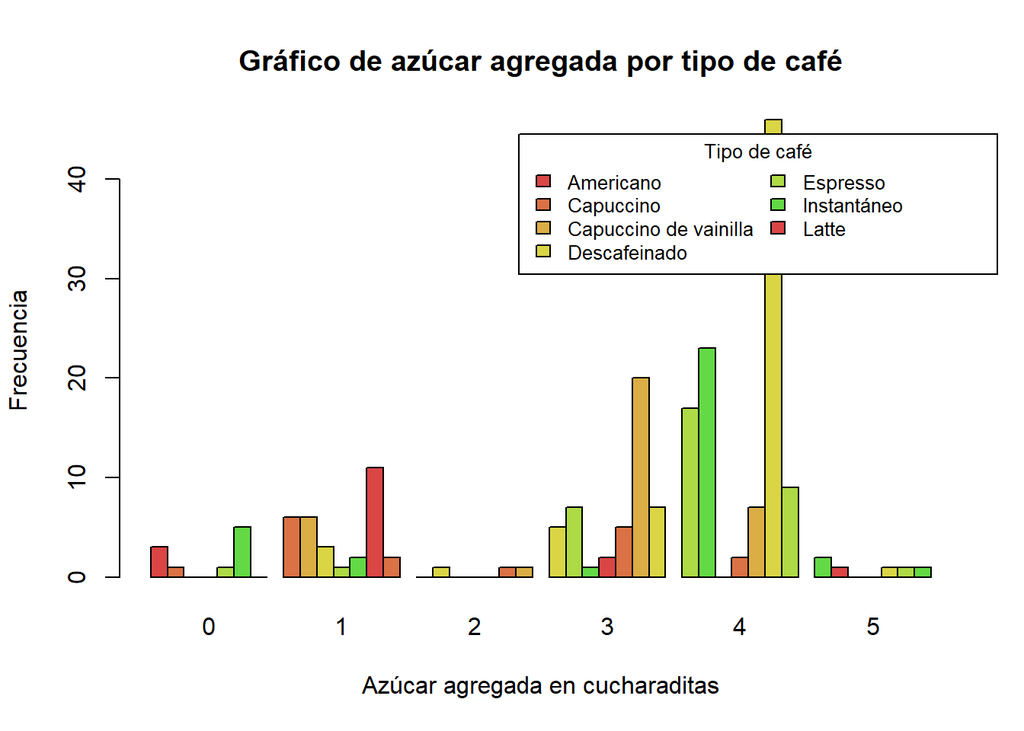

```r
A<-table(DF1$`Tipo café de consumo`,DF1$`Cucharada de azúcar`)
A<-A[1:7,]
barplot(A,main="Gráfico de azúcar agregada por tipo de café",ylab="Frecuencia",xlab="Azúcar agregada en cucharaditas",col=c("#DA4545","#DA7245","#DAAD45","#DAD545","#ADDA45","#63DA45"),legend=rownames(A),args.legend=list(title="Tipo de café",x= 52,ncol=2, cex=0.80),beside=TRUE)
```

```r
P <- table(DF1$`Tipo café de consumo`)
P
```

```
##
##             Americano             Capuccino Capuccino de vainilla
##                    33                    39                     4
##          Descafeinado              Espresso           Instantáneo
##                     5                    16                    84
##                 Latte
##                    20
```

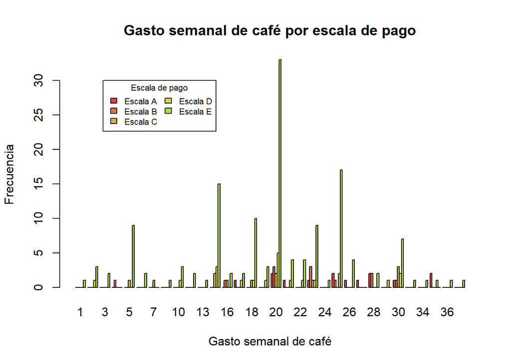

```r
M<-table(DF1$Escala,DF1$Monto)
M<-M[1:5,]
barplot(M,main="Gasto semanal de café por escala de pago",ylab="Frecuencia",xlab="Gasto semanal de café",col=c("#DA4545","#DA7245","#DAAD45","#DAD545","#ADDA45"),legend=rownames(M),args.legend=list(title="Escala de pago",x= 70, y =30,ncol=2, cex=0.70),beside=TRUE)
```

```r
P <- table(DF1$Escala)
P
```

```
##
## Escala A Escala B Escala C Escala D Escala E
##       14       12       12       22      141
```

## **III. Análisis Probabilístico**

### **Tablas Cruzadas**

**Género según la carrera a la que pertenecen**

```r
T1<-table(DF$Carrera,DF$Sexo)
T1
```

```
##
##                                       Femenino Masculino
##   Administración y Negocios Digitales        4         1
##   Bioingeniería                             11         2
##   Ciencia de Datos                           1         7
##   Ciencias de la Computación                 4         8
##   Ing. Ambiental                            39         6
##   Ing. Civil                                15        18
##   Ing. de la Energía                         5        24
##   Ing. Electrónica                          17         9
##   Ing. Industrial                           30        23
##   Ing. Mecánica                              5         8
##   Ing. Mecatrónica                           5        13
##   Ing. Química                              11        12
```

Hallamos la proporción de probabilidades.

```r
prop.T1<-round(prop.table(T1),2)
prop.T1
```

```
##
##                                       Femenino Masculino
##   Administración y Negocios Digitales     0.01      0.00
##   Bioingeniería                           0.04      0.01
##   Ciencia de Datos                        0.00      0.03
##   Ciencias de la Computación              0.01      0.03
##   Ing. Ambiental                          0.14      0.02
##   Ing. Civil                              0.05      0.06
##   Ing. de la Energía                      0.02      0.09
##   Ing. Electrónica                        0.06      0.03
##   Ing. Industrial                         0.11      0.08
##   Ing. Mecánica                           0.02      0.03
##   Ing. Mecatrónica                        0.02      0.05
##   Ing. Química                            0.04      0.04
```

**Ejercicios de probabilidad**

Probabilidad de que un estudiante sea Mujer y estudie Ingeniería Industrial

```r
p1<-prop.T1["Ing. Industrial","Femenino"]
p1
```

```
## [1] 0.11
```

Probabilidad de que un estudiante sea Hombre y estudie Ciencias de la Computación

```r
p2<-prop.T1["Ciencias de la Computación","Masculino"]
p2
```

```
## [1] 0.03
```

**Género según su consumo de café**

```r
T2<-table(DF$`Consume café`,DF$Sexo)
T2
```

```
##
##      Femenino Masculino
##   No       39        38
##   Sí      108        93
```

Hallamos la proporción de probabilidades.

```r
prop.T2<-round(prop.table(T2),2)
prop.T2
```

```
##
##      Femenino Masculino
##   No     0.14      0.14
##   Sí     0.39      0.33
```

```r
p3<-1-prop.T2["No","Femenino"]
p3
```

```
## [1] 0.86
```

Probabilidad de que sea hombre y les guste el café

```r
p4<-prop.T2["Sí","Masculino"]
p4
```

```
## [1] 0.33
```

*Gasto para café según escala de pago*

```r
T3<-table(DF1$Escala,DF1$Monto)
T3
```

```
##
##             1  2  3  4  5  6  7  8 10 12 13 15 16 17 18 19 20 21 22 23 24 25 26
##   Escala A  0  0  0  0  0  0  0  0  0  0  0  0  0  1  0  0  2  1  0  1  0  2  1
##   Escala B  0  0  0  1  0  0  0  0  0  0  0  0  1  0  0  0  3  0  0  3  0  1  0
##   Escala C  0  0  0  0  1  0  1  0  0  0  0  2  1  0  1  0  2  0  0  1  0  0  0
##   Escala D  0  1  0  0  0  0  0  0  1  0  0  3  0  1  1  1  5  1  1  1  0  2  0
##   Escala E  1  3  2  0  9  2  0  1  3  2  1 15  2  2 10  3 33  4  4  9  1 17  4
##
##            27 28 29 30 32 34 35 36 40
##   Escala A  1  2  0  1  0  0  2  0  0
##   Escala B  0  2  0  1  0  0  0  0  0
##   Escala C  0  0  0  3  0  0  0  0  0
##   Escala D  0  0  1  2  0  0  1  0  0
##   Escala E  0  2  0  7  1  1  0  1  1
```

Hallamos la proporción de probabilidades.

```r
prop.T3<-round(prop.table(T3),2)
prop.T3
```

```
##
##               1    2    3    4    5    6    7    8   10   12   13   15   16
##   Escala A 0.00 0.00 0.00 0.00 0.00 0.00 0.00 0.00 0.00 0.00 0.00 0.00 0.00
##   Escala B 0.00 0.00 0.00 0.00 0.00 0.00 0.00 0.00 0.00 0.00 0.00 0.00 0.00
##   Escala C 0.00 0.00 0.00 0.00 0.00 0.00 0.00 0.00 0.00 0.00 0.00 0.01 0.00
##   Escala D 0.00 0.00 0.00 0.00 0.00 0.00 0.00 0.00 0.00 0.00 0.00 0.01 0.00
##   Escala E 0.00 0.01 0.01 0.00 0.04 0.01 0.00 0.00 0.01 0.01 0.00 0.07 0.01
##
##              17   18   19   20   21   22   23   24   25   26   27   28   29
##   Escala A 0.00 0.00 0.00 0.01 0.00 0.00 0.00 0.00 0.01 0.00 0.00 0.01 0.00
##   Escala B 0.00 0.00 0.00 0.01 0.00 0.00 0.01 0.00 0.00 0.00 0.00 0.01 0.00
##   Escala C 0.00 0.00 0.00 0.01 0.00 0.00 0.00 0.00 0.00 0.00 0.00 0.00 0.00
##   Escala D 0.00 0.00 0.00 0.02 0.00 0.00 0.00 0.00 0.01 0.00 0.00 0.00 0.00
##   Escala E 0.01 0.05 0.01 0.16 0.02 0.02 0.04 0.00 0.08 0.02 0.00 0.01 0.00
##
##              30   32   34   35   36   40
##   Escala A 0.00 0.00 0.00 0.01 0.00 0.00
##   Escala B 0.00 0.00 0.00 0.00 0.00 0.00
##   Escala C 0.01 0.00 0.00 0.00 0.00 0.00
##   Escala D 0.01 0.00 0.00 0.00 0.00 0.00
##   Escala E 0.03 0.00 0.00 0.00 0.00 0.00
```

*ejercicios de probabilidad* La probabilidad de ser escala A y gastar 25 soles

```r
p5<-prop.T3["Escala A","25"]
p5
```

```
## [1] 0.01
```

Probabilidad de ser Escala E y gastar 25 y 30 soles.

```r
p6<-prop.T3["Escala E","25"]+prop.T3["Escala E","30"]
p6
```

```
## [1] 0.11
```

*Vasos consumidos por cantidad de horas de estudio*

```r
T4<-table(DF1$`Horas estudio`,DF1$`Vasos de café`)
T4
```

```
##
##       1  2  3  4  5  6  7
##   1   0  2  1  0  0  0  0
##   3   1  6  2  0  0  0  0
##   4   5 12  5  0  1  0  0
##   5  11 15  2  0  1  1  1
##   6  15 46  9  1  1  0  0
##   7   8 15  4  0  0  0  0
##   8   9 13  1  0  1  0  0
##   9   1  3  3  0  0  0  0
##   10  3  2  0  0  0  0  0
```

Hallamos la proporción de probabilidades.

```r
prop.T4<-round(prop.table(T4),2)
prop.T4
```

```
##
##         1    2    3    4    5    6    7
##   1  0.00 0.01 0.00 0.00 0.00 0.00 0.00
##   3  0.00 0.03 0.01 0.00 0.00 0.00 0.00
##   4  0.02 0.06 0.02 0.00 0.00 0.00 0.00
##   5  0.05 0.07 0.01 0.00 0.00 0.00 0.00
##   6  0.07 0.23 0.04 0.00 0.00 0.00 0.00
##   7  0.04 0.07 0.02 0.00 0.00 0.00 0.00
##   8  0.04 0.06 0.00 0.00 0.00 0.00 0.00
##   9  0.00 0.01 0.01 0.00 0.00 0.00 0.00
##   10 0.01 0.01 0.00 0.00 0.00 0.00 0.00
```

*ejercicios*

```r
p7<-prop.T4["7","1"]
p7
```

```
## [1] 0.04
```

```r
p6<-prop.T4["3","2"]+prop.T4["3","3"]+prop.T4["3","4"]+prop.T4["3","4"]+prop.T4["3","6"]+prop.T4["3","7"]
p6
```

```
## [1] 0.04
```

### **MODELOS PROBABILISTICOS**

#### **MODELO HYPERGEOMÉTRICO**

Se tiene una población de 278 estudiantes encuestados, se sabe que 55 de ellos consumen café en la universidad. Se escoge una muestra aleatoria de 15 estudiantes encuestados y sin reemplazo. ¿Cuál es la probabilidad de que 5 de ellos consuman café en la universidad?

```r
T6<-table(DF$`Lugar de consumo`)
T6
```

```
##
##                     Cafeterías (Starbucks, etc.)
##                                               29
##                                          De casa
##                                               70
## Tiendas de conveniencia (Tambo, Oxxo, MASS etc.)
##                                               47
##  Universidad (Café de maquina expendedora, etc.)
##                                               55
```

Hallamos la proporción de probabilidades.

```r
prop.T6<-round(prop.table(T6),2)
prop.T6
```

```
##
##                     Cafeterías (Starbucks, etc.)
##                                             0.14
##                                          De casa
##                                             0.35
## Tiendas de conveniencia (Tambo, Oxxo, MASS etc.)
##                                             0.23
##  Universidad (Café de maquina expendedora, etc.)
##                                             0.27
```

Utilizamos la distribución hypergeométrica.

```r
exito <- 55
fracaso <- 278 - 55
muestra <- 15
k <- 5
dhyper(k, exito, fracaso, muestra)
```

```
## [1] 0.09967563
```

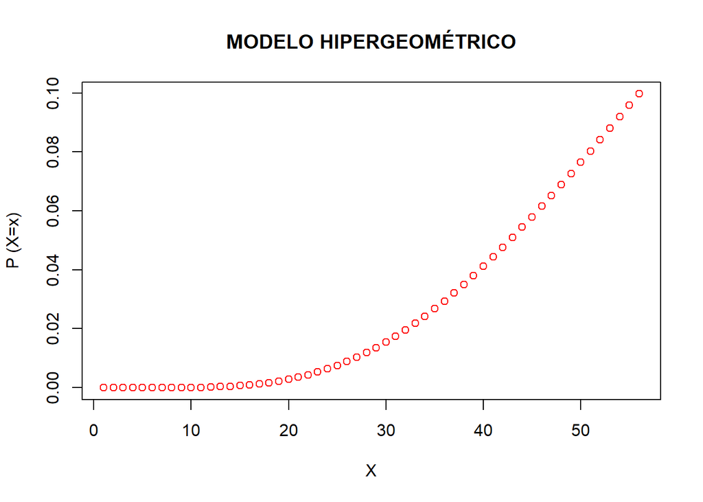

```r
plot(dhyper(5, 0:55, 278 - 55, 15),col = "red",xlab = "X",ylab = "P (X=x)",main = "MODELO HIPERGEOMÉTRICO")
```

#### **DISTRIBUCIÓN BINOMIAL NEGATIVA**

Se realiza un estudio sobré el consumo de café en los estudiantes de la UTEC, se sabe que el 53% de la población son mujeres. Si se escoge una muestra aleatoriamente. ¿Cual es la probabilidad de que en la veinteava encuesta se escoja por séptima vez la respuesta de una mujer?

```r
TBN<-table(DF$Sexo)
TBN
```

```
##
##  Femenino Masculino
##       147       131
```

Hallamos la proporción de probabilidades.

```r
prop.TBN<-round(prop.table(TBN),2)
prop.TBN
```

```
##
##  Femenino Masculino
##      0.53      0.47
```

Utilizamos la distribución binomial negativa

```r
dnbinom(20-7,7,0.53)
```

```
## [1] 0.01740544
```

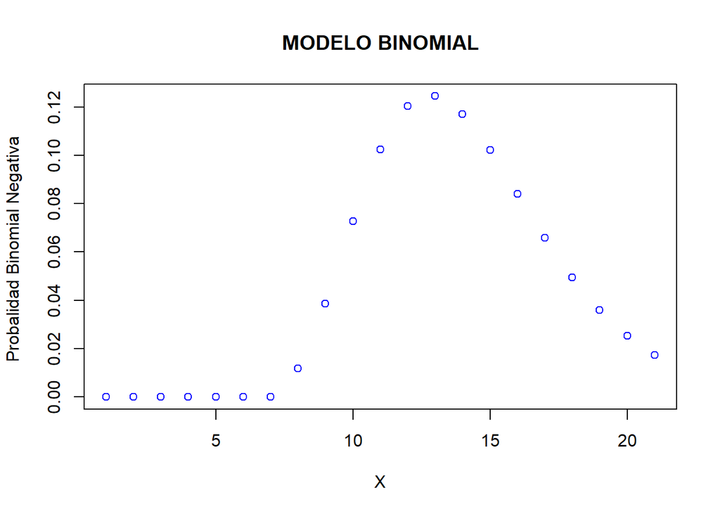

```r
plot(dnbinom(0:20-7,7,0.53),col = "Blue",xlab="X",ylab="Probalidad Binomial Negativa ",main = "MODELO BINOMIAL")
```

#### **DISTRIBUCIÓN BINOMIAL**

```r
TB<-table(DF1$`Tipo café de consumo`,DF1$Escala)
TB
```

```
##
##                         Escala A Escala B Escala C Escala D Escala E
##   Americano                    3        1        1        5       23
##   Capuccino                    3        6        4        4       22
##   Capuccino de vainilla        0        1        0        1        2
##   Descafeinado                 0        0        0        1        4
##   Espresso                     2        2        3        1        8
##   Instantáneo                  4        2        2       10       66
##   Latte                        2        0        2        0       16
```

Hallamos la proporción de probabilidades.

```r
prop.TB<-round(prop.table(TB),2)
prop.TB
```

```
##
##                         Escala A Escala B Escala C Escala D Escala E
##   Americano                 0.01     0.00     0.00     0.02     0.11
##   Capuccino                 0.01     0.03     0.02     0.02     0.11
##   Capuccino de vainilla     0.00     0.00     0.00     0.00     0.01
##   Descafeinado              0.00     0.00     0.00     0.00     0.02
##   Espresso                  0.01     0.01     0.01     0.00     0.04
##   Instantáneo               0.02     0.01     0.01     0.05     0.33
##   Latte                     0.01     0.00     0.01     0.00     0.08
```

```r
prop.TB["Americano","Escala E"]
```

```
## [1] 0.11
```

Utilizamos la distribución binomial.

```r
n=1
k=26
p=26/201
dbinom(1,26,26/201)
```

```
## [1] 0.1053902
```

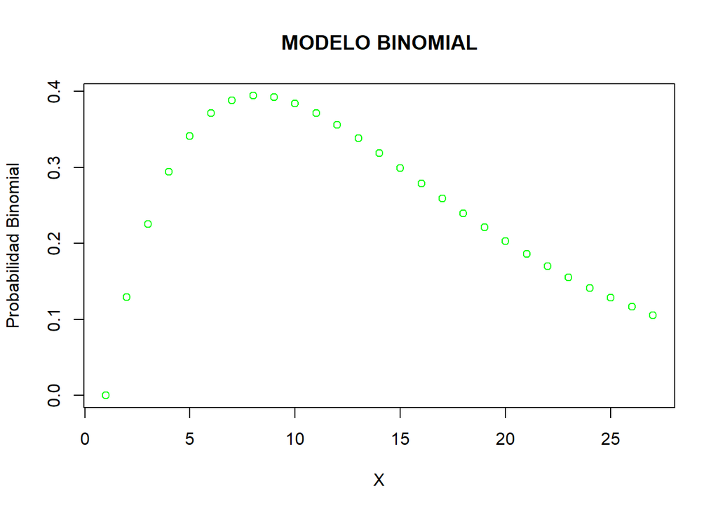

```r
n=1
k=26
p=26/201
plot(dbinom(n,0:k,p),col = "green",xlab = "X",ylab = "Probabilidad Binomial" ,main = "MODELO BINOMIAL")
```

## **IV. Bibliografía**

Llaneza, F. M. G., Cernuda, C. P., Rodríguez, A. A. I., Trujillo, F. S., & Morales, M. P. (2014). Comportamiento y factores determinantes del consumo adictivo en estudiantes de medicina: nicaragüenses, cubanos y guatemaltecos. Revista del Hospital Psiquiátrico de La Habana, 11(S1).

Park, K. (2010). A Study of College Students’ Actual Conditions of Using Coffee Shops and Choice Attributes. The korean journal of food and nutrition.

Pineda-Rodríguez, A. A. (2011). Percepción sobre el consumo de sustâncias psicoactivas por estudiantes de medicina de La provincia de Ica, Perú 2010. Revista médica panacea, 1(2).

Zaragoza Martí, A., Norte, A., Fernández-Sáez, J., Hurtado Sánchez, J. A., & Ortiz-Moncada, R. (2013). Tipo de bebidas consumidas por los estudiantes universitarios.